# Assignment 10

Kornel Kovacs

11/15/2019

## Exercise 1:

To make a conclusion and be able to interpret coefficients, I first need to replicate the models with the `simm3` dataset. We have a categorical variable, `x2` and a continous one, `x1`. This is important for understanding the equations we estimate.

```r
mod1 <- lm(y ~ x1 + x2, data = sim3)
mod2 <- lm(y ~ x1 * x2, data = sim3)

sim3 <- sim3 %>%
  add_predictions(mod1, var = "mod1") %>%
  add_predictions(mod2, var = "mod2")
```

Plotting `mod1`

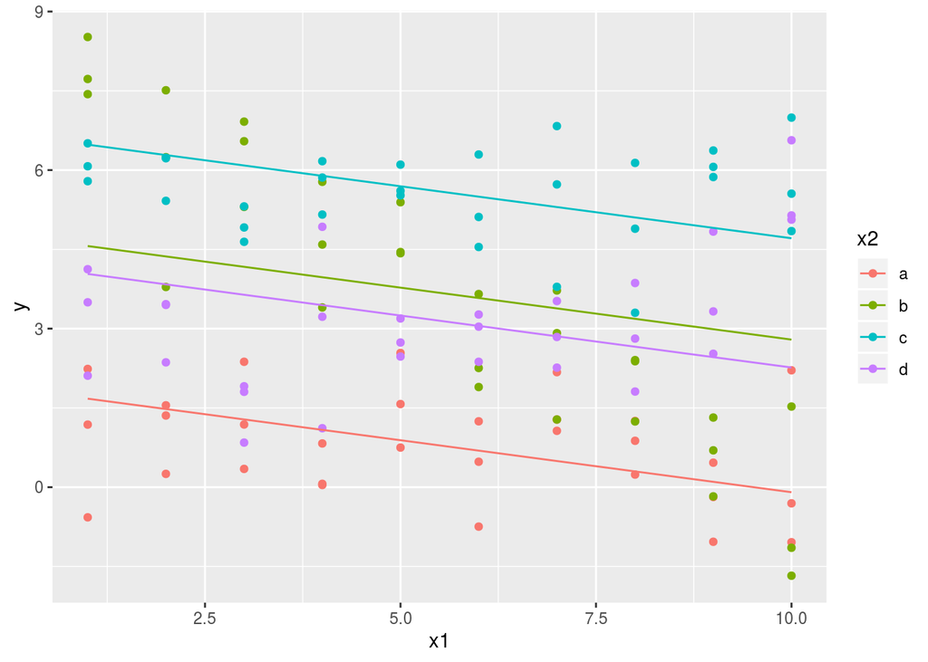

```r
ggplot(sim3, aes(x = x1, y = y, color = x2)) +
  geom_point() +
  geom_line(aes(y = mod1))
```

Making a summary of `mod1`

```r
summary(mod1)
```

```
##
## Call:
## lm(formula = y ~ x1 + x2, data = sim3)
##
## Residuals:
##     Min      1Q  Median      3Q     Max
## -4.4674 -0.8524 -0.0729  0.7886  4.3005
##
## Coefficients:
##             Estimate Std. Error t value Pr(>|t|)
## (Intercept)  1.87167    0.38738   4.832 4.22e-06 ***
## x1          -0.19674    0.04871  -4.039 9.72e-05 ***
## x2b          2.88781    0.39571   7.298 4.07e-11 ***
## x2c          4.80574    0.39571  12.145  < 2e-16 ***
## x2d          2.35959    0.39571   5.963 2.79e-08 ***
## ---
## Signif. codes:  0 '***' 0.001 '**' 0.01 '*' 0.05 '.' 0.1 ' ' 1
##
## Residual standard error: 1.533 on 115 degrees of freedom
## Multiple R-squared:  0.5911, Adjusted R-squared:  0.5768
## F-statistic: 41.55 on 4 and 115 DF,  p-value: < 2.2e-16
```

Plotting `mod2`

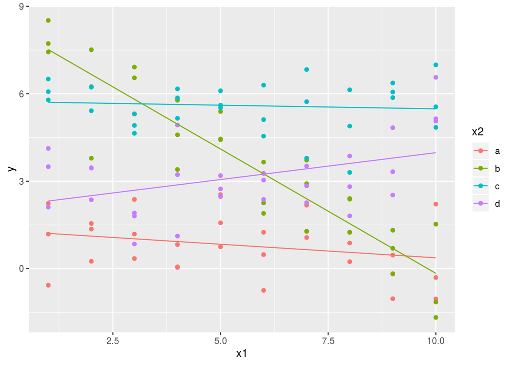

```r
ggplot(sim3, aes(x = x1, y = y, color = x2)) +
  geom_point() +
  geom_line(aes(y = mod2))
```

Making a summary of `mod2`

```r
summary(mod2)
```

```
##
## Call:
## lm(formula = y ~ x1 * x2, data = sim3)
##
## Residuals:
##      Min       1Q   Median       3Q      Max
## -2.87634 -0.67655  0.04837  0.69963  2.58607
##
## Coefficients:
##             Estimate Std. Error t value Pr(>|t|)
## (Intercept)  1.30124    0.40400   3.221  0.00167 **
## x1          -0.09302    0.06511  -1.429  0.15587
## x2b          7.06938    0.57134  12.373  < 2e-16 ***
## x2c          4.43090    0.57134   7.755 4.41e-12 ***
## x2d          0.83455    0.57134   1.461  0.14690
## x1:x2b      -0.76029    0.09208  -8.257 3.30e-13 ***
## x1:x2c       0.06815    0.09208   0.740  0.46076
## x1:x2d       0.27728    0.09208   3.011  0.00322 **
## ---
## Signif. codes:  0 '***' 0.001 '**' 0.01 '*' 0.05 '.' 0.1 ' ' 1
##
## Residual standard error: 1.024 on 112 degrees of freedom
## Multiple R-squared:  0.8221, Adjusted R-squared:  0.811
## F-statistic: 73.93 on 7 and 112 DF,  p-value: < 2.2e-16
```

### Interpretation for `Mod2`

- **(Intercept):** It is the intercept when x2 is “a”, so the intercept of the red line.
- **x2b:** It shows how much the intercept is greater when x2 equals “b” compared to the baseline case (which is x2 = “a”). Therefore, the intercept of the green line is (Intercept) + x2b, so 1.3 + 7.07 = 8.37.
- **x2c:** It shows how much the intercept is greater when x2 equals “c” compared to the baseline case (which is x2 = “a”). Therefore, the intercept of the blue line is (Intercept) + x2c, so 1.3 + 4.43 = 5.73.
- **x2d:** It shows how much the intercept is greater when x2 equals “d” compared to the baseline case (which is x2 = “a”). Therefore, the intercept of the purple line is (Intercept) + x2d, so 1.3 + 0.83 = 2.13.
- **-0.09 (coefficient of x1)** is the expected difference in y corresponding to one unit difference in x1 in case x2 equals “a”. It is also the slope of the red line in the graph. Since it is negative, the line is descending.
- **x1:x2b:** It shows how much the slope is steeper when x2 equals “b” compared to the baseline case (which is x2 = “a”). Therefore, the slope of the green line is x1 + x1:x2b, so -0.09 + -0.76 = -0.87. Since it is negative, the line is descending.
- **x1:x2c:** It shows how much the slope is steeper when x2 equals “c” compared to the baseline case (which is x2 = “a”). Therefore, the slope of the blue line is x1 + x1:x2c, so -0.09 + 0.07 = -0.02. Since it is negative, the line is descending.
- **x1:x2d:** It shows how much the slope is steeper when x2 equals “d” compared to the baseline case (which is x2 = “a”). Therefore, the slope of the purple line is x1 + x1:x2d, so -0.09 + 0.28 = 0.19. Since it is positive, the line is ascending.

## Exercise 2:

`data_grid()` is a function to find all the unique values of x1 and x2 and generates all combinations.

`gather_predictions()` is a function to add each prediction as a row.

I use their combination to create a grid to plot.

```r
grid <- sim3 %>%
  data_grid(x1, x2) %>%
  gather_predictions(mod1, mod2)
```

Visualizing the models in one graph.

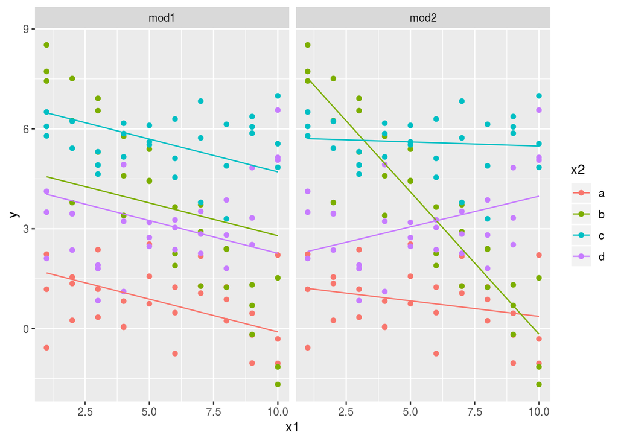

```r
ggplot(sim3, aes(x1, y, colour = x2)) +
  geom_point() +
  geom_line(data = grid, aes(y = pred)) +
  facet_wrap(~ model)
```

## Exercise 3:

In classes, we usually do not write codes that require heavy computations. However in real life, effective codes are of crucial importance. R is a very vector-oriented language. I suspect that running a `for loop` is slow compared to some sort of `apply` function. In this exercise, I intend to shed light on how much loops are slower in R.

First, I create a vector with 100 000 values. I want to create a new vector adding a uniform random number between 0 and 1 to the each and every value of the original vector. I add a random seed to ensure that we add the very same random numbers to the original vector.

```r
numbers <- c(1:100000)
```

### Loops

This for loop iterates through the original vector appending a new element to the cumulating vector in each iteration.

```r
set.seed(42)
start_time <- Sys.time()
vec <- c()
for (value in numbers) {
  vec <- c(vec, value + runif(1))
}
end_time <- Sys.time()
end_time - start_time
```

```
## Time difference of 13.71949 secs
```

### Apply-like functions

This is more like an R way of coding. I wrote a function that adds a random uniform number to a number. I applied this function to every element of my original vector.

```r
set.seed(42)
start_time <- Sys.time()
random_maker <- function(x) {
  return (x + runif(1))
}

vec <- sapply(numbers, random_maker)
end_time <- Sys.time()
end_time - start_time
```

```
## Time difference of 0.2655745 secs
```

This is ridiculously faster than the for loop. R coders should use loops rarely as they are quite slow in this R environment, furthermore, theoretically not supported.